# 💳 Capstone Project: Credit Card Fraud Detection

## Using Machine Learning

**Presented by:** dennis b.  
**Course:** Postgraduate Diploma in Artificial Intelligence and Machine Learning (PGD AIML)  
**Institution:** Asian Institute of Management  
**Date:** 2026

## 📋 Table of Contents

1. Problem Statement
2. Dataset Overview
3. Exploratory Data Analysis (EDA)
4. Data Preprocessing
5. Machine Learning Models
6. Best Model Performance
7. Feature Importance
8. Conclusion & Future Work

# 🚩 Problem Statement

Credit card fraud costs the global financial industry billions of dollars annually. According to the [Nilson Report](https://nilsonreport.com/newsletters/1232/), global card fraud losses exceeded thirty two billion dollars in 2021 and are projected to suprass $40 billion by 2027.

The core challenge is asymmetric: there are two types of errors,but their business costs are wildly different.

Error Type:

- False Negative (FN) -A fraudulent transaction is predicted as legitimate
- False Positive (FP) -A legitimate transaction is blocked

Business Cost:

- Full transaction loss +chargeback fee (~$25 - $100) + customer trust damage
- Customer friction, potential churn (~$5-$10 per declined transaction)

False Negatives are typically 5-20X more costly than False Positives. This asymmetry directly shapes our choice of:

- Evaluation metric: AUPRC (Area Under the Precision-Recall Curve) instead of AUC-ROC, because AUPRC is far more sensitive to performance on the minority (fraud) class.
- Imbalance strategy: Both SMOTE and Class Weights, with the business cost driving the final model selection.
- Decision threshold: Tuned post-training to favor recall (catching fraud) over precision.

### Objective

> Build a machine learning model that accurately **identifies fraudulent transactions** while minimizing false positives.

```python
# ============================================================
# SLIDE: Library Imports
# ============================================================

# ── Core ──────────────────────────────────────────────────────────────────────
import numpy as np
import pandas as pd
from scipy import stats
import warnings
warnings.filterwarnings('ignore')

# ── Visualisation ─────────────────────────────────────────────────────────────
import matplotlib.pyplot as plt
import matplotlib.ticker as mticker
import seaborn as sns
sns.set_theme(style='whitegrid', palette='muted', font_scale=1.1)

# ── Preprocessing ─────────────────────────────────────────────────────────────
from sklearn.model_selection import train_test_split, StratifiedKFold
from sklearn.preprocessing import StandardScaler
from sklearn.pipeline import Pipeline

# ── Imbalance handling ────────────────────────────────────────────────────────
from imblearn.over_sampling import SMOTE
from imblearn.pipeline import Pipeline as ImbPipeline

# ── Models ────────────────────────────────────────────────────────────────────
from sklearn.linear_model import LogisticRegression
from sklearn.ensemble import RandomForestClassifier, IsolationForest
from xgboost import XGBClassifier

# ── Metrics ───────────────────────────────────────────────────────────────────
from sklearn.metrics import (
    average_precision_score,
    precision_recall_curve,
    roc_auc_score,
    confusion_matrix,
    classification_report,
    f1_score
)

# ── Interpretability ──────────────────────────────────────────────────────────
import shap

# ── Plot style ──────────────────────────────────────────────────────────────
plt.rcParams.update({
    'figure.dpi': 120,
    'axes.spines.top': False,
    'axes.spines.right': False,
    'axes.titlesize': 13,
    'axes.titleweight': 'bold',
    'font.family': 'DejaVu Sans'
})
FRAUD_COLOR   = '#E74C3C'
LEGIT_COLOR   = '#2ECC71'
NEUTRAL_COLOR = '#3498DB'

print("✅ Libraries loaded.")
```

```
✅ Libraries loaded.
```

# 📊 Dataset Overview

### Dataset: [Kaggle Credit Card Fraud Detection](https://www.kaggle.com/datasets/mlg-ulb/creditcardfraud)

V1-V28 are PCA-derived components of undisclosed original features

> ⚠️ **Key Challenge:** Severe class imbalance — fraud is only ~0.17% of all transactions.

```python
df = pd.read_csv('/content/raw_creditcard.csv')
print(f"Dataset shape: {df.shape[0]:,} rows × {df.shape[1]} columns")
df.head()
```

```
Dataset shape: 284,807 rows × 31 columns
```

|  | Time | V1 | V2 | V3 | V4 | V5 | V6 | V7 | V8 | V9 | V10 | V11 | V12 | V13 | V14 | V15 | V16 | V17 | V18 | V19 | V20 | V21 | V22 | V23 | V24 | V25 | V26 | V27 | V28 | … |
| --- | --- | --- | --- | --- | --- | --- | --- | --- | --- | --- | --- | --- | --- | --- | --- | --- | --- | --- | --- | --- | --- | --- | --- | --- | --- | --- | --- | --- | --- | --- |
| 0 | 0.0000 | -1.3598 | -0.0728 | 2.5363 | 1.3782 | -0.3383 | 0.4624 | 0.2396 | 0.0987 | 0.3638 | 0.0908 | -0.5516 | -0.6178 | -0.9914 | -0.3112 | 1.4682 | -0.4704 | 0.2080 | 0.0258 | 0.4040 | 0.2514 | -0.0183 | 0.2778 | -0.1105 | 0.0669 | 0.1285 | -0.1891 | 0.1336 | -0.0211 | … |
| 1 | 0.0000 | 1.1919 | 0.2662 | 0.1665 | 0.4482 | 0.0600 | -0.0824 | -0.0788 | 0.0851 | -0.2554 | -0.1670 | 1.6127 | 1.0652 | 0.4891 | -0.1438 | 0.6356 | 0.4639 | -0.1148 | -0.1834 | -0.1458 | -0.0691 | -0.2258 | -0.6387 | 0.1013 | -0.3398 | 0.1672 | 0.1259 | -0.0090 | 0.0147 | … |
| 2 | 1.0000 | -1.3584 | -1.3402 | 1.7732 | 0.3798 | -0.5032 | 1.8005 | 0.7915 | 0.2477 | -1.5147 | 0.2076 | 0.6245 | 0.0661 | 0.7173 | -0.1659 | 2.3459 | -2.8901 | 1.1100 | -0.1214 | -2.2619 | 0.5250 | 0.2480 | 0.7717 | 0.9094 | -0.6893 | -0.3276 | -0.1391 | -0.0554 | -0.0598 | … |
| 3 | 1.0000 | -0.9663 | -0.1852 | 1.7930 | -0.8633 | -0.0103 | 1.2472 | 0.2376 | 0.3774 | -1.3870 | -0.0550 | -0.2265 | 0.1782 | 0.5078 | -0.2879 | -0.6314 | -1.0596 | -0.6841 | 1.9658 | -1.2326 | -0.2080 | -0.1083 | 0.0053 | -0.1903 | -1.1756 | 0.6474 | -0.2219 | 0.0627 | 0.0615 | … |
| 4 | 2.0000 | -1.1582 | 0.8777 | 1.5487 | 0.4030 | -0.4072 | 0.0959 | 0.5929 | -0.2705 | 0.8177 | 0.7531 | -0.8228 | 0.5382 | 1.3459 | -1.1197 | 0.1751 | -0.4514 | -0.2370 | -0.0382 | 0.8035 | 0.4085 | -0.0094 | 0.7983 | -0.1375 | 0.1413 | -0.2060 | 0.5023 | 0.2194 | 0.2152 | … |

```
========================================
 CLASS DISTRIBUTION
========================================
                 Count  Percentage (%)
Legitimate (0)  284315         99.8273
Fraud (1)          492          0.1727
```

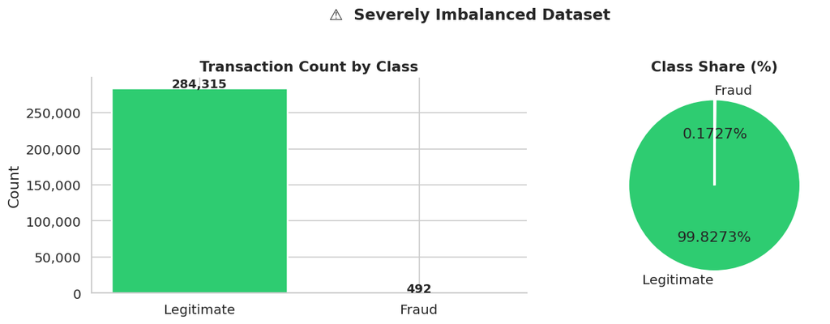

```python
# ============================================================
# SLIDE: Class Imbalance Visualization
# ============================================================
counts = df['Class'].value_counts()
pcts   = df['Class'].value_counts(normalize=True) * 100

print("=" * 40)
print(" CLASS DISTRIBUTION")
print("=" * 40)
summary = pd.DataFrame({'Count': counts, 'Percentage (%)': pcts.round(4)})
summary.index = ['Legitimate (0)', 'Fraud (1)']
print(summary.to_string())

fig, axes = plt.subplots(1, 2, figsize=(12, 4))

# Bar chart
axes[0].bar(['Legitimate', 'Fraud'], counts.values,
            color=[LEGIT_COLOR, FRAUD_COLOR], edgecolor='white', linewidth=1.5)
for i, v in enumerate(counts.values):
    axes[0].text(i, v + 200, f'{v:,}', ha='center', fontweight='bold', fontsize=11)
axes[0].set_title('Transaction Count by Class')
axes[0].set_ylabel('Count')
axes[0].yaxis.set_major_formatter(mticker.FuncFormatter(lambda x, _: f'{int(x):,}'))

# Pie chart
axes[1].pie(counts.values, labels=['Legitimate', 'Fraud'],
            colors=[LEGIT_COLOR, FRAUD_COLOR],
            autopct='%1.4f%%', startangle=90,
            wedgeprops={'edgecolor': 'white', 'linewidth': 2})
axes[1].set_title('Class Share (%)')

plt.suptitle('⚠️  Severely Imbalanced Dataset', fontsize=14, fontweight='bold', y=1.02)
plt.tight_layout()
plt.show()
```

# 🔍 Exploratory Data Analysis

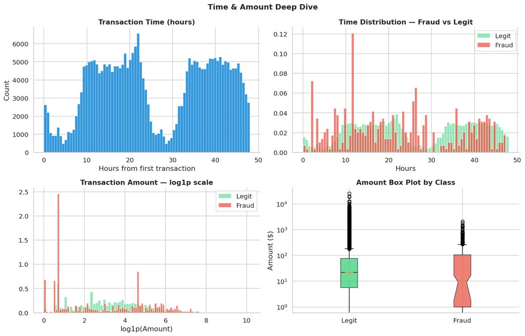

```python
# ============================================================
# SLIDE: EDA — Time & Amount distribution
# ============================================================

fig, axes = plt.subplots(2, 2, figsize=(14, 9))

# Time — overall
axes[0, 0].hist(df['Time'] / 3600, bins=80, color=NEUTRAL_COLOR, edgecolor='white', linewidth=0.3)
axes[0, 0].set_title('Transaction Time (hours)')
axes[0, 0].set_xlabel('Hours from first transaction')
axes[0, 0].set_ylabel('Count')

# Time — fraud vs legit
axes[0, 1].hist(df[df['Class'] == 0]['Time'] / 3600, bins=80, alpha=0.5,
                color=LEGIT_COLOR, label='Legit', density=True)
axes[0, 1].hist(df[df['Class'] == 1]['Time'] / 3600, bins=80, alpha=0.7,
                color=FRAUD_COLOR, label='Fraud', density=True)
axes[0, 1].set_title('Time Distribution — Fraud vs Legit')
axes[0, 1].set_xlabel('Hours')
axes[0, 1].legend()

# Amount — log scale
axes[1, 0].hist(np.log1p(df[df['Class'] == 0]['Amount']), bins=80,
                alpha=0.5, color=LEGIT_COLOR, label='Legit', density=True)
axes[1, 0].hist(np.log1p(df[df['Class'] == 1]['Amount']), bins=80,
                alpha=0.7, color=FRAUD_COLOR, label='Fraud', density=True)
axes[1, 0].set_title('Transaction Amount — log1p scale')
axes[1, 0].set_xlabel('log1p(Amount)')
axes[1, 0].legend()

# Amount — box plots by class
bp_data = [df[df['Class'] == 0]['Amount'], df[df['Class'] == 1]['Amount']]
bp = axes[1, 1].boxplot(bp_data, patch_artist=True, notch=True,
                         labels=['Legit', 'Fraud'])
for patch, color in zip(bp['boxes'], [LEGIT_COLOR, FRAUD_COLOR]):
    patch.set_facecolor(color)
    patch.set_alpha(0.7)
axes[1, 1].set_title('Amount Box Plot by Class')
axes[1, 1].set_ylabel('Amount ($)')
axes[1, 1].set_yscale('log')

plt.suptitle('Time & Amount Deep Dive', fontsize=14, fontweight='bold')
plt.tight_layout()
plt.show()
```

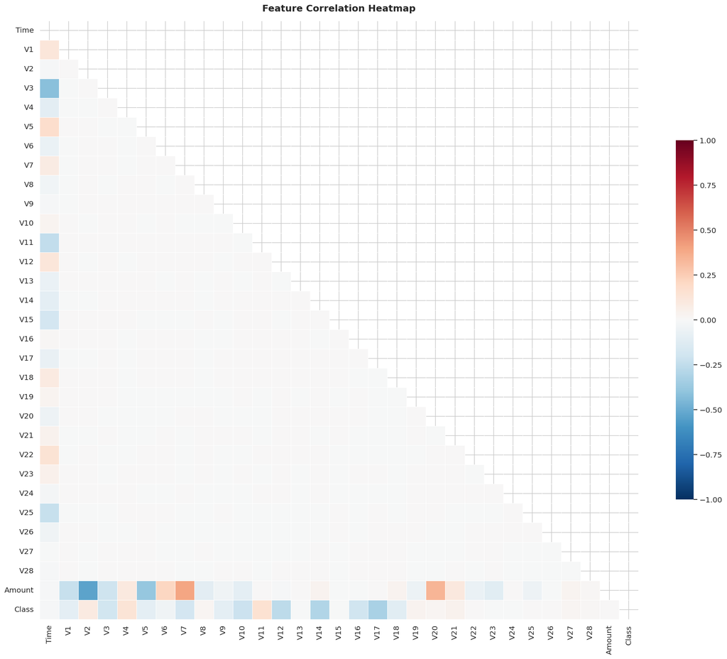

```python
# ============================================================
# SLIDE: Correlation Heatmap
# ============================================================

corr = df.corr()

fig, ax = plt.subplots(figsize=(18, 15))
mask = np.triu(np.ones_like(corr, dtype=bool))   # upper triangle only
sns.heatmap(corr, mask=mask, cmap='RdBu_r', center=0,
            annot=False, fmt='.2f', linewidths=0.3,
            vmin=-1, vmax=1, ax=ax,
            cbar_kws={'shrink': 0.6})
ax.set_title('Feature Correlation Heatmap', fontsize=15, fontweight='bold', pad=15)
plt.tight_layout()
plt.show()
```